# Risk Factor Analysis

## Outcome Variable

**Outcome Variable:** wasted

## Predictor Variables

**Intervention Variable:** predfeed3

**Adjustment Set:**

unadjusted

## Stratifying Variables

The analysis was stratified on these variable(s):

- agecat
- studyid
- country

## Data Summary

| agecat | studyid | country | predfeed3 | wasted | n_cell | n |
| --- | --- | --- | --- | --- | --- | --- |
| Birth | EE | PAKISTAN | 1 | 0 | 18 | 22 |
| Birth | EE | PAKISTAN | 1 | 1 | 4 | 22 |
| Birth | EE | PAKISTAN | 0 | 0 | 0 | 22 |
| Birth | EE | PAKISTAN | 0 | 1 | 0 | 22 |
| Birth | GMS-Nepal | NEPAL | 1 | 0 | 282 | 422 |
| Birth | GMS-Nepal | NEPAL | 1 | 1 | 70 | 422 |
| Birth | GMS-Nepal | NEPAL | 0 | 0 | 60 | 422 |
| Birth | GMS-Nepal | NEPAL | 0 | 1 | 10 | 422 |
| Birth | JiVitA-3 | BANGLADESH | 1 | 0 | 8559 | 10634 |
| Birth | JiVitA-3 | BANGLADESH | 1 | 1 | 1079 | 10634 |
| Birth | JiVitA-3 | BANGLADESH | 0 | 0 | 897 | 10634 |
| Birth | JiVitA-3 | BANGLADESH | 0 | 1 | 99 | 10634 |
| Birth | JiVitA-4 | BANGLADESH | 1 | 0 | 87 | 97 |
| Birth | JiVitA-4 | BANGLADESH | 1 | 1 | 2 | 97 |
| Birth | JiVitA-4 | BANGLADESH | 0 | 0 | 8 | 97 |
| Birth | JiVitA-4 | BANGLADESH | 0 | 1 | 0 | 97 |
| Birth | MAL-ED | BANGLADESH | 1 | 0 | 137 | 202 |
| Birth | MAL-ED | BANGLADESH | 1 | 1 | 27 | 202 |
| Birth | MAL-ED | BANGLADESH | 0 | 0 | 32 | 202 |
| Birth | MAL-ED | BANGLADESH | 0 | 1 | 6 | 202 |
| Birth | MAL-ED | BRAZIL | 1 | 0 | 23 | 55 |
| Birth | MAL-ED | BRAZIL | 1 | 1 | 0 | 55 |
| Birth | MAL-ED | BRAZIL | 0 | 0 | 31 | 55 |
| Birth | MAL-ED | BRAZIL | 0 | 1 | 1 | 55 |
| Birth | MAL-ED | INDIA | 1 | 0 | 23 | 39 |
| Birth | MAL-ED | INDIA | 1 | 1 | 4 | 39 |
| Birth | MAL-ED | INDIA | 0 | 0 | 11 | 39 |
| Birth | MAL-ED | INDIA | 0 | 1 | 1 | 39 |
| Birth | MAL-ED | NEPAL | 1 | 0 | 12 | 25 |
| Birth | MAL-ED | NEPAL | 1 | 1 | 2 | 25 |

[output cut: 102 more lines]

The following strata were considered:

- agecat: 24 months, studyid: EE, country: PAKISTAN
- agecat: 24 months, studyid: GMS-Nepal, country: NEPAL
- agecat: 24 months, studyid: JiVitA-3, country: BANGLADESH
- agecat: 24 months, studyid: JiVitA-4, country: BANGLADESH
- agecat: 24 months, studyid: MAL-ED, country: BANGLADESH
- agecat: 24 months, studyid: MAL-ED, country: BRAZIL
- agecat: 24 months, studyid: MAL-ED, country: INDIA
- agecat: 24 months, studyid: MAL-ED, country: NEPAL
- agecat: 24 months, studyid: MAL-ED, country: PERU
- agecat: 24 months, studyid: MAL-ED, country: SOUTH AFRICA
- agecat: 24 months, studyid: MAL-ED, country: TANZANIA, UNITED REPUBLIC OF
- agecat: 6 months, studyid: EE, country: PAKISTAN
- agecat: 6 months, studyid: GMS-Nepal, country: NEPAL
- agecat: 6 months, studyid: JiVitA-3, country: BANGLADESH
- agecat: 6 months, studyid: JiVitA-4, country: BANGLADESH
- agecat: 6 months, studyid: MAL-ED, country: BANGLADESH
- agecat: 6 months, studyid: MAL-ED, country: BRAZIL
- agecat: 6 months, studyid: MAL-ED, country: INDIA
- agecat: 6 months, studyid: MAL-ED, country: NEPAL
- agecat: 6 months, studyid: MAL-ED, country: PERU
- agecat: 6 months, studyid: MAL-ED, country: SOUTH AFRICA
- agecat: 6 months, studyid: MAL-ED, country: TANZANIA, UNITED REPUBLIC OF
- agecat: Birth, studyid: EE, country: PAKISTAN
- agecat: Birth, studyid: GMS-Nepal, country: NEPAL
- agecat: Birth, studyid: JiVitA-3, country: BANGLADESH
- agecat: Birth, studyid: JiVitA-4, country: BANGLADESH
- agecat: Birth, studyid: MAL-ED, country: BANGLADESH
- agecat: Birth, studyid: MAL-ED, country: BRAZIL
- agecat: Birth, studyid: MAL-ED, country: INDIA
- agecat: Birth, studyid: MAL-ED, country: NEPAL
- agecat: Birth, studyid: MAL-ED, country: PERU
- agecat: Birth, studyid: MAL-ED, country: SOUTH AFRICA
- agecat: Birth, studyid: MAL-ED, country: TANZANIA, UNITED REPUBLIC OF

### Dropped Strata

Some strata were dropped due to rare outcomes:

- agecat: Birth, studyid: EE, country: PAKISTAN
- agecat: Birth, studyid: JiVitA-4, country: BANGLADESH
- agecat: Birth, studyid: MAL-ED, country: BRAZIL
- agecat: Birth, studyid: MAL-ED, country: INDIA
- agecat: Birth, studyid: MAL-ED, country: NEPAL
- agecat: Birth, studyid: MAL-ED, country: PERU
- agecat: Birth, studyid: MAL-ED, country: SOUTH AFRICA
- agecat: Birth, studyid: MAL-ED, country: TANZANIA, UNITED REPUBLIC OF
- agecat: 6 months, studyid: EE, country: PAKISTAN
- agecat: 6 months, studyid: JiVitA-4, country: BANGLADESH
- agecat: 6 months, studyid: MAL-ED, country: BANGLADESH
- agecat: 6 months, studyid: MAL-ED, country: BRAZIL
- agecat: 6 months, studyid: MAL-ED, country: NEPAL
- agecat: 6 months, studyid: MAL-ED, country: PERU
- agecat: 6 months, studyid: MAL-ED, country: SOUTH AFRICA
- agecat: 6 months, studyid: MAL-ED, country: TANZANIA, UNITED REPUBLIC OF
- agecat: 24 months, studyid: EE, country: PAKISTAN
- agecat: 24 months, studyid: JiVitA-4, country: BANGLADESH
- agecat: 24 months, studyid: MAL-ED, country: BANGLADESH
- agecat: 24 months, studyid: MAL-ED, country: BRAZIL
- agecat: 24 months, studyid: MAL-ED, country: NEPAL
- agecat: 24 months, studyid: MAL-ED, country: PERU
- agecat: 24 months, studyid: MAL-ED, country: SOUTH AFRICA
- agecat: 24 months, studyid: MAL-ED, country: TANZANIA, UNITED REPUBLIC OF

## Methods Detail

We’re interested in the causal parameters $E[Y_a]$ for all values of $a \in \mathcal{A}$. These parameters represent the mean outcome if, possibly contrary to fact, we intervened to set all units to have $A=a$. Under the randomization and positivity assumptions, these are identified by the statistical parameters $\psi_a=E_W[E_{Y|A,W}(Y|A=a,W)]$. In addition, we’re interested in the mean of $Y$, $E[Y]$ under no intervention (the observed mean). We will estimate these parameters by using SuperLearner to fit the relevant likelihood factors – $E_{Y|A,W}(Y|A=a,W)$ and $p(A=a|W)$, and then updating our likelihood fit using a joint TMLE.

For unadjusted analyses ($W=\{\}$), initial likelihoods were estimated using Lrnr_glm to estimate the simple $E(Y|A)$ and Lrnr_mean to estimate $p(A)$. For adjusted analyses, a small library containing Lrnr_glmnet, Lrnr_xgboost, and Lrnr_mean was used.

Having estimated these parameters, we will then use the delta method to estimate relative risks and attributable risks relative to a prespecified baseline level of $A$.

# Results Detail

## Results Plots

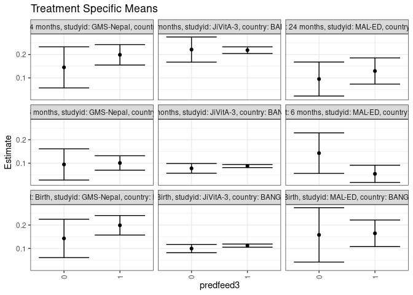

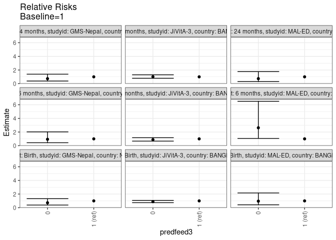

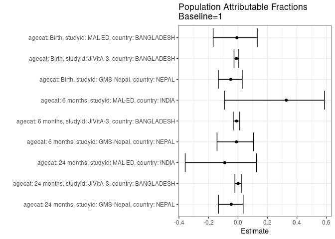

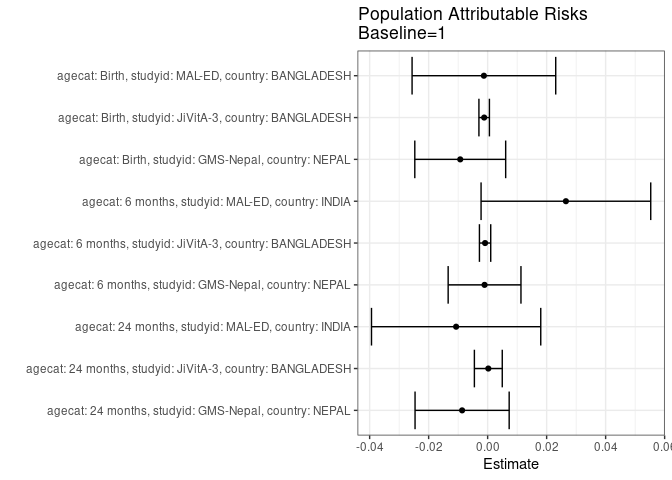

## Results Table

### Parameter: TSM

| agecat | studyid | country | intervention_level | baseline_level | estimate | ci_lower | ci_upper |
| --- | --- | --- | --- | --- | --- | --- | --- |
| Birth | GMS-Nepal | NEPAL | 1 | NA | 0.1988636 | 0.1571169 | 0.2406104 |
| Birth | GMS-Nepal | NEPAL | 0 | NA | 0.1428571 | 0.0607857 | 0.2249285 |
| Birth | JiVitA-3 | BANGLADESH | 1 | NA | 0.1119527 | 0.1051856 | 0.1187197 |
| Birth | JiVitA-3 | BANGLADESH | 0 | NA | 0.0993976 | 0.0816509 | 0.1171442 |
| Birth | MAL-ED | BANGLADESH | 1 | NA | 0.1646341 | 0.1077355 | 0.2215328 |
| Birth | MAL-ED | BANGLADESH | 0 | NA | 0.1578947 | 0.0416694 | 0.2741201 |
| 6 months | GMS-Nepal | NEPAL | 1 | NA | 0.1008174 | 0.0699785 | 0.1316564 |
| 6 months | GMS-Nepal | NEPAL | 0 | NA | 0.0945946 | 0.0278402 | 0.1613490 |
| 6 months | JiVitA-3 | BANGLADESH | 1 | NA | 0.0877647 | 0.0810760 | 0.0944534 |
| 6 months | JiVitA-3 | BANGLADESH | 0 | NA | 0.0777778 | 0.0569976 | 0.0985579 |
| 6 months | MAL-ED | INDIA | 1 | NA | 0.0544218 | 0.0176630 | 0.0911805 |
| 6 months | MAL-ED | INDIA | 0 | NA | 0.1428571 | 0.0562424 | 0.2294719 |
| 24 months | GMS-Nepal | NEPAL | 1 | NA | 0.1987578 | 0.1551132 | 0.2424023 |
| 24 months | GMS-Nepal | NEPAL | 0 | NA | 0.1451613 | 0.0573630 | 0.2329596 |
| 24 months | JiVitA-3 | BANGLADESH | 1 | NA | 0.2184741 | 0.2042001 | 0.2327481 |
| 24 months | JiVitA-3 | BANGLADESH | 0 | NA | 0.2211538 | 0.1674266 | 0.2748810 |
| 24 months | MAL-ED | INDIA | 1 | NA | 0.1294964 | 0.0735422 | 0.1854506 |
| 24 months | MAL-ED | INDIA | 0 | NA | 0.0952381 | 0.0225726 | 0.1679035 |

### Parameter: E(Y)

| agecat | studyid | country | intervention_level | baseline_level | estimate | ci_lower | ci_upper |
| --- | --- | --- | --- | --- | --- | --- | --- |
| Birth | GMS-Nepal | NEPAL | NA | NA | 0.1895735 | 0.1521320 | 0.2270149 |
| Birth | JiVitA-3 | BANGLADESH | NA | NA | 0.1107768 | 0.1043978 | 0.1171557 |
| Birth | MAL-ED | BANGLADESH | NA | NA | 0.1633663 | 0.1122571 | 0.2144755 |
| 6 months | GMS-Nepal | NEPAL | NA | NA | 0.0997732 | 0.0717702 | 0.1277763 |
| 6 months | JiVitA-3 | BANGLADESH | NA | NA | 0.0868958 | 0.0805887 | 0.0932029 |
| 6 months | MAL-ED | INDIA | NA | NA | 0.0809524 | 0.0439731 | 0.1179317 |
| 24 months | GMS-Nepal | NEPAL | NA | NA | 0.1901042 | 0.1508072 | 0.2294011 |
| 24 months | JiVitA-3 | BANGLADESH | NA | NA | 0.2187047 | 0.2046312 | 0.2327783 |
| 24 months | MAL-ED | INDIA | NA | NA | 0.1188119 | 0.0740803 | 0.1635435 |

### Parameter: RR

| agecat | studyid | country | intervention_level | baseline_level | estimate | ci_lower | ci_upper |
| --- | --- | --- | --- | --- | --- | --- | --- |
| Birth | GMS-Nepal | NEPAL | 1 | 1 | 1.0000000 | 1.0000000 | 1.000000 |
| Birth | GMS-Nepal | NEPAL | 0 | 1 | 0.7183673 | 0.3896809 | 1.324293 |
| Birth | JiVitA-3 | BANGLADESH | 1 | 1 | 1.0000000 | 1.0000000 | 1.000000 |
| Birth | JiVitA-3 | BANGLADESH | 0 | 1 | 0.8878535 | 0.7360338 | 1.070989 |
| Birth | MAL-ED | BANGLADESH | 1 | 1 | 1.0000000 | 1.0000000 | 1.000000 |
| Birth | MAL-ED | BANGLADESH | 0 | 1 | 0.9590643 | 0.4252885 | 2.162777 |
| 6 months | GMS-Nepal | NEPAL | 1 | 1 | 1.0000000 | 1.0000000 | 1.000000 |
| 6 months | GMS-Nepal | NEPAL | 0 | 1 | 0.9382761 | 0.4348109 | 2.024701 |
| 6 months | JiVitA-3 | BANGLADESH | 1 | 1 | 1.0000000 | 1.0000000 | 1.000000 |
| 6 months | JiVitA-3 | BANGLADESH | 0 | 1 | 0.8862079 | 0.6694997 | 1.173062 |
| 6 months | MAL-ED | INDIA | 1 | 1 | 1.0000000 | 1.0000000 | 1.000000 |
| 6 months | MAL-ED | INDIA | 0 | 1 | 2.6250000 | 1.0591134 | 6.506031 |
| 24 months | GMS-Nepal | NEPAL | 1 | 1 | 1.0000000 | 1.0000000 | 1.000000 |
| 24 months | GMS-Nepal | NEPAL | 0 | 1 | 0.7303427 | 0.3837740 | 1.389882 |
| 24 months | JiVitA-3 | BANGLADESH | 1 | 1 | 1.0000000 | 1.0000000 | 1.000000 |
| 24 months | JiVitA-3 | BANGLADESH | 0 | 1 | 1.0122658 | 0.7897996 | 1.297395 |
| 24 months | MAL-ED | INDIA | 1 | 1 | 1.0000000 | 1.0000000 | 1.000000 |
| 24 months | MAL-ED | INDIA | 0 | 1 | 0.7354497 | 0.3060169 | 1.767505 |

### Parameter: PAR

| agecat | studyid | country | intervention_level | baseline_level | estimate | ci_lower | ci_upper |
| --- | --- | --- | --- | --- | --- | --- | --- |
| Birth | GMS-Nepal | NEPAL | 1 | NA | -0.0092902 | -0.0246930 | 0.0061127 |
| Birth | JiVitA-3 | BANGLADESH | 1 | NA | -0.0011759 | -0.0029552 | 0.0006033 |
| Birth | MAL-ED | BANGLADESH | 1 | NA | -0.0012678 | -0.0256142 | 0.0230785 |
| 6 months | GMS-Nepal | NEPAL | 1 | NA | -0.0010442 | -0.0133851 | 0.0112967 |
| 6 months | JiVitA-3 | BANGLADESH | 1 | NA | -0.0008689 | -0.0027820 | 0.0010442 |
| 6 months | MAL-ED | INDIA | 1 | NA | 0.0265306 | -0.0022268 | 0.0552880 |
| 24 months | GMS-Nepal | NEPAL | 1 | NA | -0.0086536 | -0.0246070 | 0.0072998 |
| 24 months | JiVitA-3 | BANGLADESH | 1 | NA | 0.0002307 | -0.0044942 | 0.0049555 |
| 24 months | MAL-ED | INDIA | 1 | NA | -0.0106845 | -0.0393719 | 0.0180028 |

### Parameter: PAF

| agecat | studyid | country | intervention_level | baseline_level | estimate | ci_lower | ci_upper |
| --- | --- | --- | --- | --- | --- | --- | --- |
| Birth | GMS-Nepal | NEPAL | 1 | NA | -0.0490057 | -0.1331673 | 0.0289051 |
| Birth | JiVitA-3 | BANGLADESH | 1 | NA | -0.0106153 | -0.0267641 | 0.0052794 |
| Birth | MAL-ED | BANGLADESH | 1 | NA | -0.0077605 | -0.1683589 | 0.1307626 |
| 6 months | GMS-Nepal | NEPAL | 1 | NA | -0.0104657 | -0.1420133 | 0.1059291 |
| 6 months | JiVitA-3 | BANGLADESH | 1 | NA | -0.0099993 | -0.0322288 | 0.0117515 |
| 6 months | MAL-ED | INDIA | 1 | NA | 0.3277311 | -0.0921984 | 0.5862057 |
| 24 months | GMS-Nepal | NEPAL | 1 | NA | -0.0455203 | -0.1326078 | 0.0348709 |
| 24 months | JiVitA-3 | BANGLADESH | 1 | NA | 0.0010547 | -0.0207758 | 0.0224182 |
| 24 months | MAL-ED | INDIA | 1 | NA | -0.0899281 | -0.3581162 | 0.1253008 |